# Assignment 3

# There are a few interesting observation from above pair plot that:

# Campaign (number of contacts made) with clients who have approx. mode balance amount with bank deposits were made majorly not with those who were outliers (Very high or no balance).

# Duration of the call is also higher for clients who have approx. mode balance amount with bank deposits were made majorly not with those who were outliers (Very high or no balance).

# pdays (number of days past) are lower for clients who have approx. mode balance amount with bank deposits were made majorly not with those who were outliers (Very high or no balance).

Observed correlation between Duration, Campaign and pdays with balance

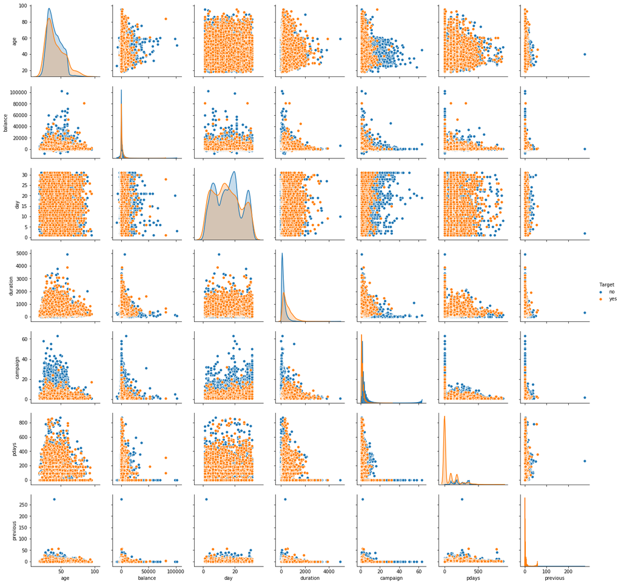

```python
sns.pairplot(bankdata, hue = 'Target')
```

# Pair plot provides an interesting observation that pdays(days past from last contact), if more means if teh days contacted are more then the chances of coversion is very high.

# Meaning that there is a ripe time for any target client coversion, if the days past more- client takes time to make decision and hence conversion.

# Creation of X and y for the data given

# Converson of String (Object) variables in to Categorical variables

```python
for feature in bankdata.columns:
    if bankdata[feature].dtype =='object':
        bankdata[feature]=pd.Categorical(bankdata[feature])
bankdata.info()
```

```
<class 'pandas.core.frame.DataFrame'>
RangeIndex: 45211 entries, 0 to 45210
Data columns (total 17 columns):
age          45211 non-null int64
job          45211 non-null category
marital      45211 non-null category
education    45211 non-null category
default      45211 non-null category
balance      45211 non-null int64
housing      45211 non-null category
loan         45211 non-null category
contact      45211 non-null category
day          45211 non-null int64
month        45211 non-null category
duration     45211 non-null int64
campaign     45211 non-null int64
pdays        45211 non-null int64
previous     45211 non-null int64
poutcome     45211 non-null category
Target       45211 non-null category
dtypes: category(10), int64(7)
memory usage: 2.8 MB
```

```python
# Now as we can see, all data types are either Numerical or Categorical, the next step is to identify the variable that are ordered in nature
```

# In Order to covert the Categorical Variables in to ordered one, we will first see the variations (type of value sets) in Categorical data and then decide the order

```python
print(bankdata.marital.value_counts())
print(bankdata.education.value_counts())
print(bankdata.default.value_counts())
print(bankdata.housing.value_counts())
print(bankdata.loan.value_counts())
print(bankdata.contact.value_counts())
print(bankdata.poutcome.value_counts())
print(bankdata.Target.value_counts())
```

```
married     27214
single      12790
divorced     5207
Name: marital, dtype: int64
secondary    23202
tertiary     13301
primary       6851
unknown       1857
Name: education, dtype: int64
no     44396
yes      815
Name: default, dtype: int64
yes    25130
no     20081
Name: housing, dtype: int64
no     37967
yes     7244
Name: loan, dtype: int64
cellular     29285
unknown      13020
telephone     2906
Name: contact, dtype: int64
unknown    36959
failure     4901
other       1840
success     1511
Name: poutcome, dtype: int64
no     39922
yes     5289
Name: Target, dtype: int64
```

# Replacing the Categories: education, default, housing, loan, poutcome and Target as Ordered variables; and job, marital, contact and month as one hot encoding

```python
replaceStruct ={
    "education":{"primary": 1,"secondary": 2,"tertiary": 3,"unknown": -1},
    "default": {"no":0,"yes":1},
    "housing":{"no":0,"yes":1},
    "loan":{"no":0,"yes":1},
    "poutcome":{"failure":0,"success":1,"other":2,"unknown":-1},
    "Target":{"no":0,"yes":1}
}
oneHotCols =["job","marital","contact","month"]
```

```python
bankdata = bankdata.replace(replaceStruct)
bankdata = pd.get_dummies(bankdata, columns = oneHotCols)
bankdata.head()
```

|  | age | education | default | balance | housing | loan | day | duration | campaign | pdays | ... | month_dec | month_feb | month_jan | month_jul | month_jun | month_mar | month_may | month_nov | month_oct | month_sep |
| --- | --- | --- | --- | --- | --- | --- | --- | --- | --- | --- | --- | --- | --- | --- | --- | --- | --- | --- | --- | --- | --- |
| 0 | 58 | 3 | 0 | 2143 | 1 | 0 | 5 | 261 | 1 | -1 | ... | 0 | 0 | 0 | 0 | 0 | 0 | 1 | 0 | 0 | 0 |
| 1 | 44 | 2 | 0 | 29 | 1 | 0 | 5 | 151 | 1 | -1 | ... | 0 | 0 | 0 | 0 | 0 | 0 | 1 | 0 | 0 | 0 |
| 2 | 33 | 2 | 0 | 2 | 1 | 1 | 5 | 76 | 1 | -1 | ... | 0 | 0 | 0 | 0 | 0 | 0 | 1 | 0 | 0 | 0 |
| 3 | 47 | -1 | 0 | 1506 | 1 | 0 | 5 | 92 | 1 | -1 | ... | 0 | 0 | 0 | 0 | 0 | 0 | 1 | 0 | 0 | 0 |
| 4 | 33 | -1 | 0 | 1 | 0 | 0 | 5 | 198 | 1 | -1 | ... | 0 | 0 | 0 | 0 | 0 | 0 | 1 | 0 | 0 | 0 |

5 rows × 43 columns

```python
bankdata.info()
```

```
<class 'pandas.core.frame.DataFrame'>
RangeIndex: 45211 entries, 0 to 45210
Data columns (total 43 columns):
age                  45211 non-null int64
education            45211 non-null int64
default              45211 non-null int64
balance              45211 non-null int64
housing              45211 non-null int64
loan                 45211 non-null int64
day                  45211 non-null int64
duration             45211 non-null int64
campaign             45211 non-null int64
pdays                45211 non-null int64
previous             45211 non-null int64
poutcome             45211 non-null int64
Target               45211 non-null int64
job_admin.           45211 non-null uint8
job_blue-collar      45211 non-null uint8
job_entrepreneur     45211 non-null uint8
job_housemaid        45211 non-null uint8
job_management       45211 non-null uint8
job_retired          45211 non-null uint8
job_self-employed    45211 non-null uint8
job_services         45211 non-null uint8
job_student          45211 non-null uint8
job_technician       45211 non-null uint8
job_unemployed       45211 non-null uint8
job_unknown          45211 non-null uint8
marital_divorced     45211 non-null uint8
marital_married      45211 non-null uint8
marital_single       45211 non-null uint8
contact_cellular     45211 non-null uint8
contact_telephone    45211 non-null uint8
contact_unknown      45211 non-null uint8
month_apr            45211 non-null uint8
month_aug            45211 non-null uint8
month_dec            45211 non-null uint8
month_feb            45211 non-null uint8
month_jan            45211 non-null uint8
month_jul            45211 non-null uint8
month_jun            45211 non-null uint8
month_mar            45211 non-null uint8
month_may            45211 non-null uint8
month_nov            45211 non-null uint8
month_oct            45211 non-null uint8
month_sep            45211 non-null uint8
dtypes: int64(13), uint8(30)
memory usage: 5.8 MB
```

# We can observe that all the data has been converted to numerical

# Data Split

```python
X0 = bankdata.drop("Target",axis=1 )
X = X0.drop("duration", axis =1)
y = bankdata.pop("Target")
```

```python
# Split X and y in to train and test set in the ratio 70:30
```

```python
from sklearn.model_selection import train_test_split

X_train, X_test, y_train, y_test = train_test_split(X,y, test_size=.30, random_state=1)
```

```python
# As in our data, the balance, age,duration and education varies from decimal to hundreds in scale, it is better that we scale/ normalise our x data
```

```python
from scipy.stats import zscore
XScale = X.apply(zscore)
XScale.describe()
```

|  | age | education | default | balance | housing | loan | day | campaign | pdays | previous | ... | month_dec | month_feb | month_jan | month_jul | month_jun | month_mar | month_may | month_nov | month_oct | month_sep |
| --- | --- | --- | --- | --- | --- | --- | --- | --- | --- | --- | --- | --- | --- | --- | --- | --- | --- | --- | --- | --- | --- |
| count | 4.521100e+04 | 4.521100e+04 | 4.521100e+04 | 4.521100e+04 | 4.521100e+04 | 4.521100e+04 | 4.521100e+04 | 4.521100e+04 | 4.521100e+04 | 4.521100e+04 | ... | 4.521100e+04 | 4.521100e+04 | 4.521100e+04 | 4.521100e+04 | 4.521100e+04 | 4.521100e+04 | 4.521100e+04 | 4.521100e+04 | 4.521100e+04 | 4.521100e+04 |
| mean | 5.222844e-16 | -3.427835e-14 | 4.520540e-15 | 3.070663e-15 | 1.382298e-14 | -1.275129e-14 | -9.219436e-15 | 1.254699e-14 | -1.395817e-13 | 1.355210e-13 | ... | -3.656326e-14 | -1.176170e-13 | -1.624319e-14 | -3.537936e-14 | 1.672611e-14 | 1.406700e-14 | 7.421982e-14 | -9.714164e-14 | -5.102876e-14 | 5.457301e-14 |
| std | 1.000011e+00 | 1.000011e+00 | 1.000011e+00 | 1.000011e+00 | 1.000011e+00 | 1.000011e+00 | 1.000011e+00 | 1.000011e+00 | 1.000011e+00 | 1.000011e+00 | ... | 1.000011e+00 | 1.000011e+00 | 1.000011e+00 | 1.000011e+00 | 1.000011e+00 | 1.000011e+00 | 1.000011e+00 | 1.000011e+00 | 1.000011e+00 | 1.000011e+00 |
| min | -2.159994e+00 | -3.344586e+00 | -1.354899e-01 | -3.081149e+00 | -1.118674e+00 | -4.368035e-01 | -1.779108e+00 | -5.693506e-01 | -4.114531e-01 | -2.519404e-01 | ... | -6.896284e-02 | -2.494767e-01 | -1.789584e-01 | -4.242062e-01 | -3.660060e-01 | -1.032620e-01 | -6.616496e-01 | -3.102635e-01 | -1.288190e-01 | -1.138980e-01 |
| 25% | -7.473845e-01 | -2.153577e-02 | -1.354899e-01 | -4.237719e-01 | -1.118674e+00 | -4.368035e-01 | -9.380027e-01 | -5.693506e-01 | -4.114531e-01 | -2.519404e-01 | ... | -6.896284e-02 | -2.494767e-01 | -1.789584e-01 | -4.242062e-01 | -3.660060e-01 | -1.032620e-01 | -6.616496e-01 | -3.102635e-01 | -1.288190e-01 | -1.138980e-01 |
| 50% | -1.823406e-01 | -2.153577e-02 | -1.354899e-01 | -3.002800e-01 | 8.939154e-01 | -4.368035e-01 | 2.326031e-02 | -2.465603e-01 | -4.114531e-01 | -2.519404e-01 | ... | -6.896284e-02 | -2.494767e-01 | -1.789584e-01 | -4.242062e-01 | -3.660060e-01 | -1.032620e-01 | -6.616496e-01 | -3.102635e-01 | -1.288190e-01 | -1.138980e-01 |
| 75% | 6.652252e-01 | 1.086148e+00 | -1.354899e-01 | 2.158743e-02 | 8.939154e-01 | -4.368035e-01 | 6.240497e-01 | 7.622994e-02 | -4.114531e-01 | -2.519404e-01 | ... | -6.896284e-02 | -2.494767e-01 | -1.789584e-01 | -4.242062e-01 | -3.660060e-01 | -1.032620e-01 | 1.511374e+00 | -3.102635e-01 | -1.288190e-01 | -1.138980e-01 |
| max | 5.091402e+00 | 1.086148e+00 | 7.380625e+00 | 3.309478e+01 | 8.939154e-01 | 2.289359e+00 | 1.825628e+00 | 1.944365e+01 | 8.297431e+00 | 1.191360e+02 | ... | 1.450056e+01 | 4.008391e+00 | 5.587890e+00 | 2.357344e+00 | 2.732196e+00 | 9.684109e+00 | 1.511374e+00 | 3.223067e+00 | 7.762829e+00 | 8.779785e+00 |

8 rows × 41 columns

# Model 1: Classification using Logistic Regression

```python
from sklearn.linear_model import LogisticRegression

# Fitting the model to train data
model = LogisticRegression(solver ='liblinear')
model.fit(X_train,y_train)

# prediction on test data
y_predict = model.predict(X_test)

coef_df = pd.DataFrame(model.coef_)


print(coef_df)

print('intercept of the model=', model.intercept_)
```

```
         0         1         2         3         4         5         6   \
0 -0.000665  0.070433 -0.227112  0.000022 -0.562663 -0.419161  0.001661

         7         8         9    ...         31        32        33  \
0 -0.100686 -0.001126  0.014297   ...    0.51418 -0.443176 -1.043637

         34       35        36        37        38        39      40
0 -0.621845  0.28922  1.043078 -0.436939 -0.800041  0.847321  0.8246

[1 rows x 41 columns]
intercept of the model= [-0.6800931]
```

```python
model_performance = model.score(X_test,y_test)
print(model_performance)
```

```
0.8886021822471247
```

Model performance for Logistic Regression Model is 0.89

# Model 1 Confusion Matrix for Logistic Regression

```
[[  172  1379]
 [  132 11881]]
```

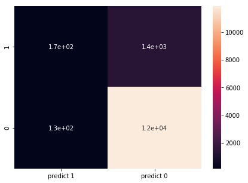

```python
from sklearn.metrics import confusion_matrix

cm = confusion_matrix(y_test,y_predict, labels =[1,0])
print(cm)

df_cm = pd.DataFrame(cm, index = [i for i in ['1','0']],
                     columns = [i for i in ['predict 1','predict 0']])
plt.figure(figsize=(7,5))
sns.heatmap(df_cm, annot = True)
```

The Confusion Matrix: True Positive: Correctly predicted Target clients = 172

True Negative: Correctly predicted Non Target clients = 11881

False Positive: Incorrectly predicted Target clients but Non Target clients = 132

False Negative: Incorrectly predicted Non Target clients but actually Target clients = 1379

# Model 1 Performance measure: ROC curve

```python
from sklearn.metrics import roc_curve, auc
probas = model.fit(X_train, y_train).predict_proba(X_test)
```

```python
# calculate ROC and Area Under the curve for our Logixtic Regression Model
fpr, tpr, thresholds = roc_curve(y_test, probas[:,1])
roc_auc = auc(fpr,tpr)
print('Area under the curve: %f' % roc_auc)
```

```
Area under the curve: 0.761747
```

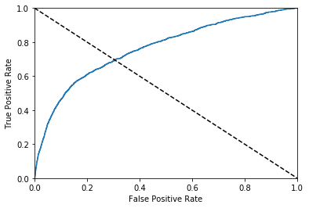

```python
#Plot ROC curve

import pylab as pl
pl.clf()
pl.plot(fpr,tpr,label = 'ROC curve for Logistic Regression( area= %0.2f)'%roc_auc)
pl.plot([0,1],[1,0],'k--')
pl.xlim([0.0,1.0])
pl.ylim([0.0,1.0])
pl.xlabel('False Positive Rate')
pl.ylabel('True Positive Rate')
pl.show()
```

# Ensemble learning (Bagging) for Model 1 (LR)

```python
# We will be using only Bagging Ensemble Learning for our observation

from sklearn.ensemble import BaggingClassifier
bgcl1 = BaggingClassifier(base_estimator= model, n_estimators=50, random_state = 1)
bgcl1 = bgcl1.fit(X_train, y_train)

y_pred_LREB = bgcl1.predict(X_test)
print(bgcl1.score(X_test,y_test))
```

```
0.8883810085520495
```

Model performance for Ensemble Learning with Logistic Regression as base estimator is 0.89

# Confusion Matrix for Ensemble Learning with Logistic Regression as base Estimator

```
[[  167  1384]
 [  130 11883]]
```

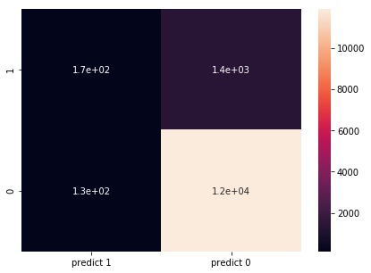

```python
from sklearn.metrics import confusion_matrix

cmeb1 = confusion_matrix(y_test,y_pred_LREB, labels =[1,0])
print(cmeb1)

df_cmeb1 = pd.DataFrame(cmeb1, index = [i for i in ['1','0']],
                     columns = [i for i in ['predict 1','predict 0']])
plt.figure(figsize=(7,5))
sns.heatmap(df_cmeb1, annot = True)
```

```
The Confusion Matrix:
True Positive: Correctly predicted Target clients = 167

True Negative: Correctly predicted Non Target clients = 11883
False Positive: Incorrectly predicted Target clients but Non Target clients = 130

False Negative: Incorrectly predicted Non Target clients but actually Target clients = 1384
```

# We see there is no benefit for using Bagging Ensemble Learning with LR as base estimator

# Model 2: Classification using KNN

```python
# Building KNN model
from sklearn.neighbors import KNeighborsClassifier
NNH = KNeighborsClassifier(n_neighbors=7, weights ='distance')
NNH.fit(X_train, y_train)
y_pred_KNN =NNH.predict(X_test)
NNH.score(X_test,y_test)
```

```
0.8814508994396933
```

Model performance for KNN Model is 0.88

# Model 2 Confusion Matrix for KNN

```
[[  190  1361]
 [  247 11766]]
```

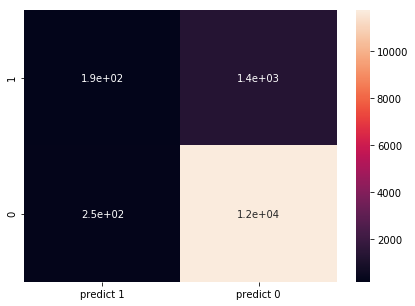

```python
from sklearn.metrics import confusion_matrix

cm_KNN = confusion_matrix(y_test,y_pred_KNN, labels =[1,0])
print(cm_KNN)

df_cmKNN = pd.DataFrame(cm_KNN, index = [i for i in ['1','0']],
                     columns = [i for i in ['predict 1','predict 0']])
plt.figure(figsize=(7,5))
sns.heatmap(df_cmKNN, annot = True)
```

The Confusion Matrix: True Positive: Correctly predicted Target clients = 190

True Negative: Correctly predicted Non Target clients = 11766

False Positive: Incorrectly predicted Target clients but Non Target clients = 247

False Negative: Incorrectly predicted Non Target clients but actually Target clients = 1361

# Model 2 Performance measure: ROC curve

```
Area under the curve: 0.618221
```

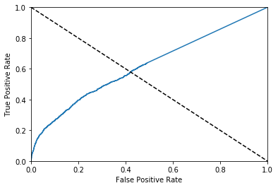

```python
from sklearn.metrics import roc_curve, auc
probas = NNH.fit(X_train, y_train).predict_proba(X_test)

# calculate ROC and Area Under the curve for our KNN Model
fpr_KNN, tpr_KNN, thresholds = roc_curve(y_test, probas[:,1])
roc_auc_KNN = auc(fpr_KNN,tpr_KNN)
print('Area under the curve: %f' % roc_auc_KNN)


#Plot ROC curve

import pylab as pl
pl.clf()
pl.plot(fpr_KNN,tpr_KNN,label = 'ROC curve for KNN Classifier( area= %0.2f)'%roc_auc_KNN)
pl.plot([0,1],[1,0],'k--')
pl.xlim([0.0,1.0])
pl.ylim([0.0,1.0])
pl.xlabel('False Positive Rate')
pl.ylabel('True Positive Rate')
pl.show()
```

# Ensemble Learning - Bagging with Model 2 (KNN)

```python
# We will be using only Bagging Ensemble Learning for our observation

from sklearn.ensemble import BaggingClassifier
bgcl2 = BaggingClassifier(base_estimator= NNH, n_estimators=50, random_state = 1)
bgcl2 = bgcl2.fit(X_train, y_train)

y_pred_KNEB = bgcl2.predict(X_test)
print(bgcl2.score(X_test,y_test))
```

```
0.8824830433500442
```

Model performance for Ensemble Learning with KNN as base estimator is 0.88

# Confusion Matrix for Ensemble Learning with KNN as base Estimator

```
[[  165  1386]
 [  208 11805]]
```

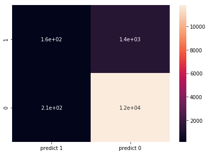

```python
from sklearn.metrics import confusion_matrix

cmeb2 = confusion_matrix(y_test,y_pred_KNEB, labels =[1,0])
print(cmeb2)

df_cmeb2 = pd.DataFrame(cmeb2, index = [i for i in ['1','0']],
                     columns = [i for i in ['predict 1','predict 0']])
plt.figure(figsize=(7,5))
sns.heatmap(df_cmeb2, annot = True)
```

The Confusion Matrix: True Positive: Correctly predicted Target clients = 165

True Negative: Correctly predicted Non Target clients = 11805

False Positive: Incorrectly predicted Target clients but Non Target clients = 208

False Negative: Incorrectly predicted Non Target clients but actually Target clients = 1386

# We see very less or not significan improvement with using Ensemble learning with KNN

# Model 3: Classification using Naive Bayes algorithm

```python
# Training of the model
from sklearn import metrics
from sklearn.naive_bayes import GaussianNB
NB_model = GaussianNB()
NB_model.fit(X_train, y_train.ravel())

#performnce using train data
NB_train_predict = NB_model.predict(X_train)

print('model Accuracy: {0:.4f}'.format(metrics.accuracy_score(y_train,NB_train_predict)))
print()
```

```
model Accuracy: 0.8252
```

Model performance for Naive Bayes Model is 0.82

# Model 3 Confusion Matrix for Naive Bayes

```
[[  660   891]
 [ 1503 10510]]
```

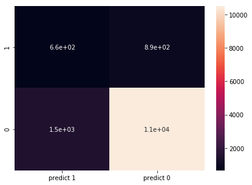

```python
from sklearn.metrics import confusion_matrix
NB_test_predict = NB_model.predict(X_test)
cm_NB = confusion_matrix(y_test,NB_test_predict, labels =[1,0])
print(cm_NB)

df_cmNB = pd.DataFrame(cm_NB, index = [i for i in ['1','0']],
                     columns = [i for i in ['predict 1','predict 0']])
plt.figure(figsize=(7,5))
sns.heatmap(df_cmNB, annot = True)
```

The Confusion Matrix: True Positive: Correctly predicted Target clients = 660

True Negative: Correctly predicted Non Target clients = 10510

False Negative: Incorrectly predicted Non Target clients but actually Target clients = 891

# Model 3 Performance measure: ROC curve

```
Area under the curve: 0.737509
```

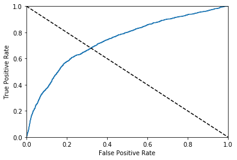

```python
from sklearn.metrics import roc_curve, auc
probas = NB_model.fit(X_train, y_train).predict_proba(X_test)

# calculate ROC and Area Under the curve for our NB Model
fpr_NB, tpr_NB, thresholds = roc_curve(y_test, probas[:,1])
roc_auc_NB = auc(fpr_NB,tpr_NB)
print('Area under the curve: %f' % roc_auc_NB)


#Plot ROC curve

import pylab as pl
pl.clf()
pl.plot(fpr_NB,tpr_NB,label = 'ROC curve for NB Classifier( area= %0.2f)'%roc_auc_NB)
pl.plot([0,1],[1,0],'k--')
pl.xlim([0.0,1.0])
pl.ylim([0.0,1.0])
pl.xlabel('False Positive Rate')
pl.ylabel('True Positive Rate')
pl.show()
```

# Ensemble Learning - Bagging with Model 3 (Naive Bayes)

```python
# We will be using only Bagging Ensemble Learning for our observation

from sklearn.ensemble import BaggingClassifier
bgcl3 = BaggingClassifier(base_estimator= NB_model, n_estimators=50, random_state = 1)
bgcl3 = bgcl3.fit(X_train, y_train)

y_pred_NBEB = bgcl3.predict(X_test)
print(bgcl3.score(X_test,y_test))
```

```
0.8237982895900914
```

Model performance for Ensemble Learning with Naive Bayes as base estimator is 0.82

# Confusion Matrix for Ensemble Learning with Naive Bayes as base Estimator

```
[[  667   884]
 [ 1506 10507]]
```

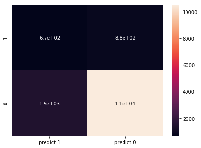

```python
from sklearn.metrics import confusion_matrix

cmeb3 = confusion_matrix(y_test,y_pred_NBEB, labels =[1,0])
print(cmeb3)

df_cmeb3 = pd.DataFrame(cmeb3, index = [i for i in ['1','0']],
                     columns = [i for i in ['predict 1','predict 0']])
plt.figure(figsize=(7,5))
sns.heatmap(df_cmeb3, annot = True)
```

The Confusion Matrix: True Positive: Correctly predicted Target clients = 667

True Negative: Correctly predicted Non Target clients = 10507

False Positive: Incorrectly predicted Target clients but Non Target clients = 1506

False Negative: Incorrectly predicted Non Target clients but actually Target clients = 884

# Not much improvement is seen in classifiction usig Ensemble Learning with Naive bayes as base estimator

# Model 4: Classification using Decision Tree Model

```python
#Building Decision Tree model using Gini criteria
from sklearn.tree import DecisionTreeClassifier
dTree = DecisionTreeClassifier(criterion ='gini', random_state =1)
dTree.fit(X_train, y_train)
```

```
DecisionTreeClassifier(class_weight=None, criterion='gini', max_depth=None,
            max_features=None, max_leaf_nodes=None,
            min_impurity_decrease=0.0, min_impurity_split=None,
            min_samples_leaf=1, min_samples_split=2,
            min_weight_fraction_leaf=0.0, presort=False, random_state=1,
            splitter='best')
```

```python
#evalating Decision Tree
print(dTree.score(X_train,y_train))
print(dTree.score(X_test, y_test))
```

```
1.0
0.8308021232674727
```

# We observe that our decision tree is overfitting as the accuracy with Training set is 100% while with Test set is only 83%

Reducing Overfitting of Decision Tree

```python
dTreeR = DecisionTreeClassifier(criterion ='gini',max_depth= 3, random_state =1)
dTreeR.fit(X_train, y_train)
print(dTreeR.score(X_train,y_train))
print(dTreeR.score(X_test, y_test))
```

```
0.8917116946314027
0.895532291359481
```

Model performance for Decision Tree is 0.89

# The Accuracy of Decision tree is increased for test data as well and is same as Train data, hence now the tree is good

```python
#Learning about the Feature Imprtance on the basis of reducing the total criterion by the individual features- called Gini importance

print(pd.DataFrame(dTreeR.feature_importances_,columns = ['Imp'], index= X_train.columns))
```

```
                        Imp
age                0.115487
education          0.000000
default            0.000000
balance            0.000000
housing            0.052414
loan               0.000000
day                0.000000
campaign           0.000000
pdays              0.000000
previous           0.000000
poutcome           0.746718
job_admin.         0.000000
job_blue-collar    0.000000
job_entrepreneur   0.000000
job_housemaid      0.000000
job_management     0.000000
job_retired        0.000000
job_self-employed  0.000000
job_services       0.000000
job_student        0.000000
job_technician     0.000000
job_unemployed     0.000000
job_unknown        0.000000
marital_divorced   0.005002
marital_married    0.000000
marital_single     0.000000
contact_cellular   0.000000
contact_telephone  0.000000
contact_unknown    0.000000
month_apr          0.000000
month_aug          0.000000
month_dec          0.000000
month_feb          0.000000
month_jan          0.000000
month_jul          0.000000
month_jun          0.000000
month_mar          0.000000
month_may          0.000000
month_nov          0.000000
month_oct          0.080378
month_sep          0.000000
```

# Model 4 Confusion Matrix for Decision Tree

```
0.895532291359481
[[11850   163]
 [ 1254   297]]
```

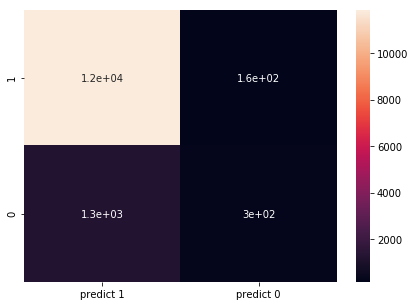

```python
from sklearn.metrics import confusion_matrix

print(dTreeR.score(X_test,y_test))
y_predictDT = dTreeR.predict(X_test)
cm_DT = metrics.confusion_matrix(y_test, y_predictDT, labels =[0,1])
print(cm_DT)

df_cmDT = pd.DataFrame(cm_DT, index = [i for i in ['1','0']],
                     columns = [i for i in ['predict 1','predict 0']])
plt.figure(figsize=(7,5))
sns.heatmap(df_cmDT, annot = True)
```

# Model 4 Performance measure: ROC curve

```
Area under the curve: 0.634009
```

[figure not shown]

```python
from sklearn.metrics import roc_curve, auc
probas = dTreeR.fit(X_train, y_train).predict_proba(X_test)

# calculate ROC and Area Under the curve for our NB Model
fpr_DT, tpr_DT, thresholds = roc_curve(y_test, probas[:,1])
roc_auc_DT = auc(fpr_DT,tpr_DT)
print('Area under the curve: %f' % roc_auc_DT)


#Plot ROC curve

import pylab as pl
pl.clf()
pl.plot(fpr_NB,tpr_NB,label = 'ROC curve for NB Classifier( area= %0.2f)'%roc_auc_DT)
pl.plot([0,1],[1,0],'k--')
pl.xlim([0.0,1.0])
pl.ylim([0.0,1.0])
pl.xlabel('False Positive Rate')
pl.ylabel('True Positive Rate')
pl.show()
```

# Ensemble Learning - Random Forest with Model 4 (Decision Tree)

```python
from sklearn.ensemble import RandomForestClassifier
rfcl = RandomForestClassifier(n_estimators = 50, random_state = 1, max_features = 10)
rfcl = rfcl.fit(X_train, y_train)
```

```
0.8948687702742554
[[11756   257]
 [ 1169   382]]
```

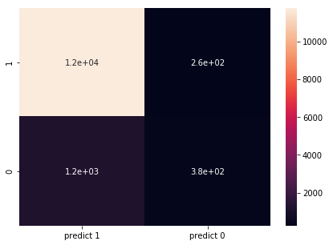

```python
y_pred_rf = rfcl.predict(X_test)
print(rfcl.score(X_test,y_test))

cm_RF = metrics.confusion_matrix(y_test, y_pred_rf, labels =[0,1])
print(cm_RF)

df_cmRF = pd.DataFrame(cm_RF, index = [i for i in ['1','0']],
                     columns = [i for i in ['predict 1','predict 0']])
plt.figure(figsize=(7,5))
sns.heatmap(df_cmRF, annot = True)
```